# act_report

## Insights And Visualization Report

### Overview

I wrangled (and analyzing and visualizing) was the tweet archive of Twitter user [@dog_rates](https://twitter.com/dog_rates), also known as WeRateDogs. WeRateDogs is a Twitter account that rates people's dogs with a humorous comment about the dog.

## Insight #1: Which breed is most common?

To get the most common dog breed in this dataset, I used to cleaned dataset to get the value_counts of the dog_breed column(i.e the counts of each dog breed) and got the top 10. The result showed that Golden Retriever is the most common dog breed in this dataset(covers over 9% of the data sample), followed by Labrador Retriever(cover over 6% of the data sample).

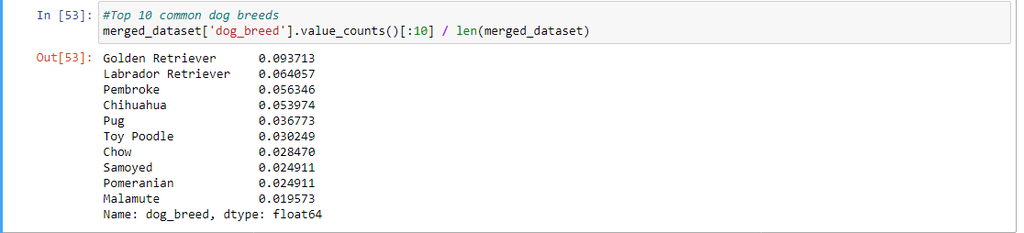

## Insight #2: Which dog breed were best predicted?

I used groupby fuction to group the dataset into dog breed and their mean confidence level. I got the top 10 best prediction using the nlargest() function. The result showed that the Komondor breed is the No1 best image prediction with cinfidence level of 0.972531, followed by Clumber and Keeshond with confidence level of 0.946718 & 0.84431 respectively.I then queried the top three for their URLs and displayed their images.

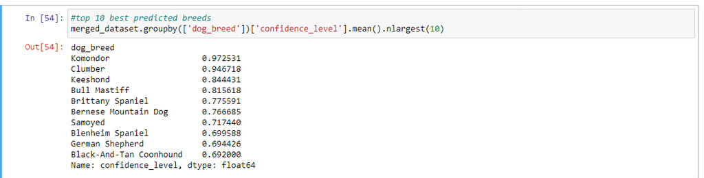

### The Komondor breed

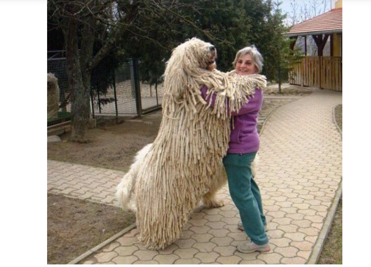

### The Clumber breed

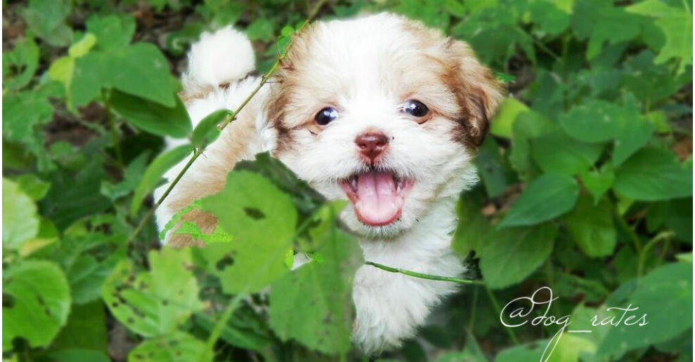

### The Keeshond breed

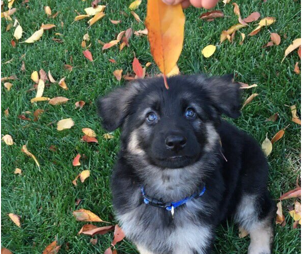

## Insight #3: What is the relationship between favorite_count and retweet_count?

I plotted a scatter plot to show the correlation between favorite_count and retweet_count. The visual showed a positive correlation between them. As the favorite_counts increases, the retweets also increases. This makes sense because a well liked tweet is more likely to get retweeted.

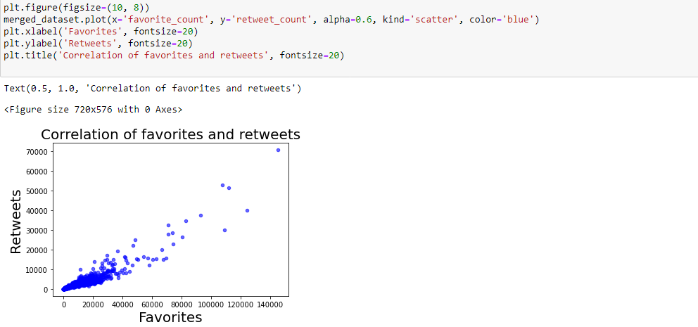